**Chapter 7: Density-dependent population change**

## Overview

Although we have emphasized that logistic growth is just one special form of negative density dependence, it turns out that wolves reintroduced into the northern rockies exhibit negative density dependence that can be reasonably modeled using logistic growth. Ever since wolves were introduced into Yellowstone and Central Idaho, the USFWS has kept a pretty good tab on total wolf numbers in the US Northern Rockies. For this exercise we will use these data from 1995-2015 (representing the total wolf count in Yellowstone, Central Idaho and NW Montana).

## Estimating population growth and carrying capacity

Eyeballing from plotting abundance over the years, what is the approximate carrying capacity for wolves in the US Northern Rockies?

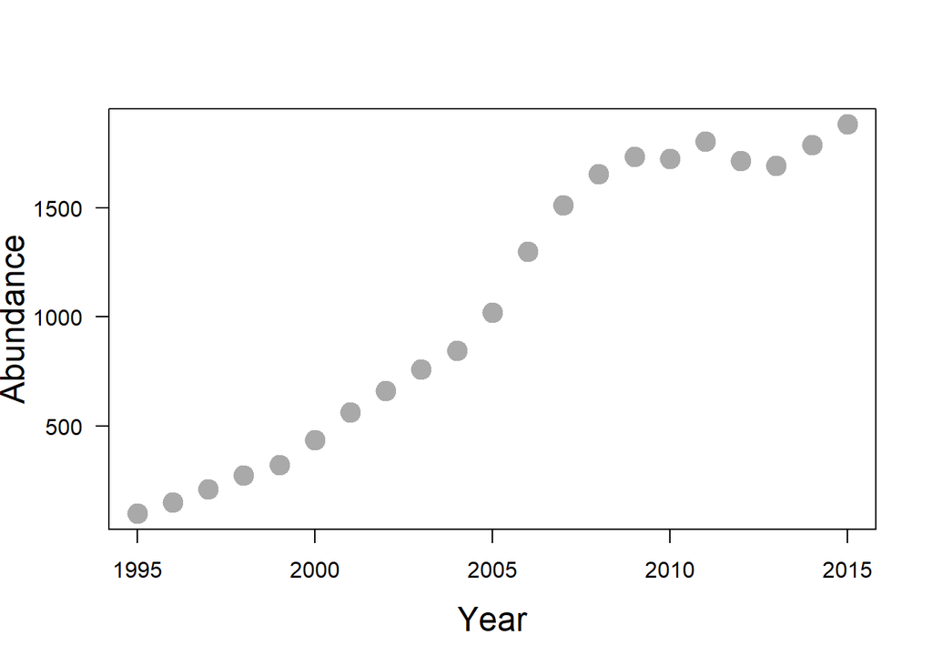

```r
wolf_data <- data.frame(year = 1995:2015,
                        N    = c(101, 152, 213, 275, 322, 437, 563, 663, 761,
                                 846, 1020, 1300, 1513, 1655, 1733, 1723, 1804,
                                 1715, 1691, 1787, 1881))

plot(wolf_data$year,
     wolf_data$N,
     ylab     = "Abundance",
     xlab     = "Year",
     cex.lab  = 1.5,
     pch      = 19,
     col      = "darkgray",
     cex      = 2,
     xaxt     = "n",
     las      = 2)
axis(1)
```

Let’s calculate per capita exponential growth rate $\rho_t$. Notice that even though the growth seems pretty steady in the previous graph, it actually fluctuates quite a bit year to year.

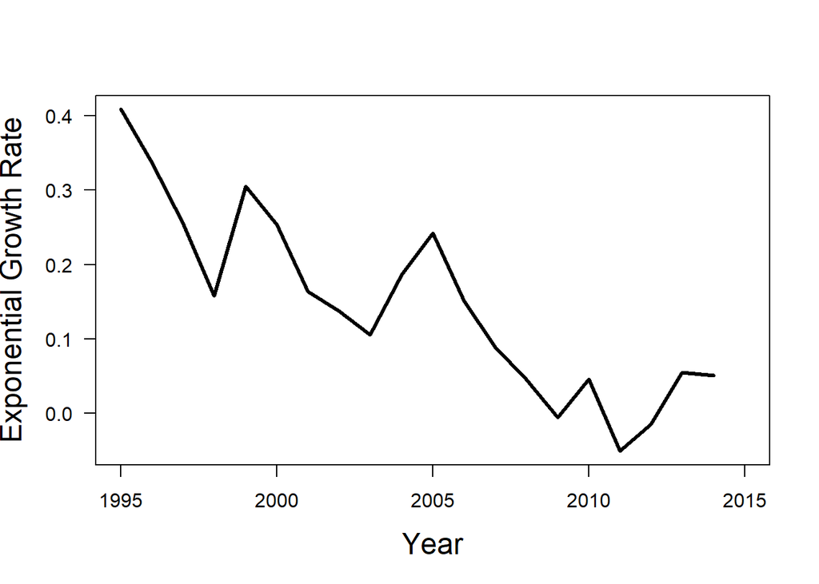

```r
rho_t <- NA
for(t in 1 : length(wolf_data$N)) {
  rho_t[t] <- log(wolf_data$N[t + 1] / wolf_data$N[t])
}

plot(wolf_data$year,
     rho_t,
     ylab    = "Exponential Growth Rate",
     xlab    = "Year",
     cex.lab = 1.5,
     pch     = 19,
     cex     = 2,
     xaxt    = "n",
     type    = "l",
     lwd     = 3,
     las     = 2)
axis(1)
```

In order to determine the intercept of the linear relationship between N and $\rho$ we can use a linear regression. This is $\rho_0$ for the logistic growth model. Now, plot the fitted line from the linear model over the plot of $\rho$ against N using R function abline().

```r
mod <- lm(rho_t ~ wolf_data$N)   # linear regression model
summary(mod)
```

```
##
## Call:
## lm(formula = rho_t ~ wolf_data$N)
##
## Residuals:
##      Min       1Q   Median       3Q      Max
## -0.11400 -0.04566  0.01070  0.03776  0.10740
##
## Coefficients:
##               Estimate Std. Error t value Pr(>|t|)
## (Intercept)  3.185e-01  2.574e-02   12.37 3.07e-10 ***
## wolf_data$N -1.700e-04  2.157e-05   -7.88 3.04e-07 ***
## ---
## Signif. codes:  0 '***' 0.001 '**' 0.01 '*' 0.05 '.' 0.1 ' ' 1
##
## Residual standard error: 0.06074 on 18 degrees of freedom
##   (1 observation deleted due to missingness)
## Multiple R-squared:  0.7753, Adjusted R-squared:  0.7628
## F-statistic: 62.09 on 1 and 18 DF,  p-value: 3.039e-07
```

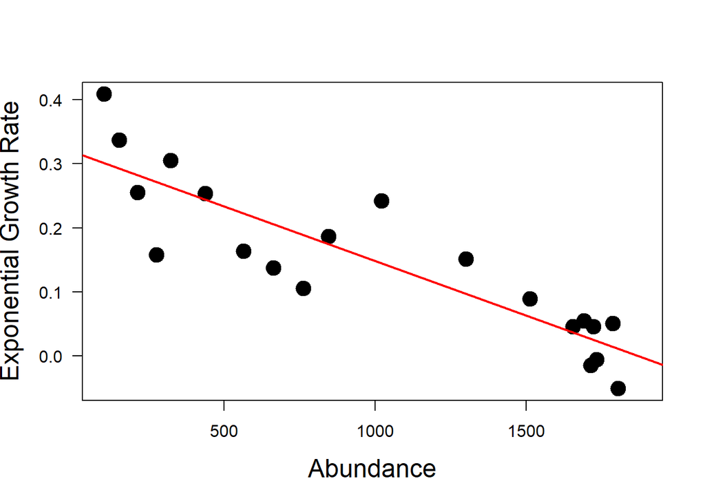

```r
plot(wolf_data$N,
     rho_t,
     ylab    = "Exponential Growth Rate",
     xlab    = "Abundance",
     cex.lab = 1.5,
     pch     = 19,
     cex     = 2,
     xaxt    = "n",
     las     = 2)
axis(1)

abline(mod, col = "red", lwd = 2)
```

Looking at the model output, the first coefficient is the intercept and the second coefficient is the slope of the red line. With these two numbers we can calculate the carrying capacity K.

```r
rho_0 <- mod$coefficients[1]
slope <- mod$coefficients[2]

K <- rho_0 / abs(slope)
```

## Logistic growth model

Let’s see how well these two parameters ($\rho_0$ and K) characterize our wolf population under a logistic growth model. First, we project the wolf population 50 years using an initial abundance of 101 and the discrete form of the logistic growth equation.

```r
n_year <- 50
N_t <- rep(NA, n_year)
N_t[1] <- 101

for (t in 2 : n_year - 1) {

  # discrete logistic growth equation
  N_t[t + 1] <- N_t[t] * exp(rho_0 * (1 - (N_t[t] / K)))
}
```

We can now visualize the estimated abundance as a line graph and add the data points for comparison. As you see with this visualization, the logistic growth model fits the data very well. The wolf population appears to be experiencing density dependent growth with an exponential increase in growth initially that slowed to a carrying capacity around 1874.

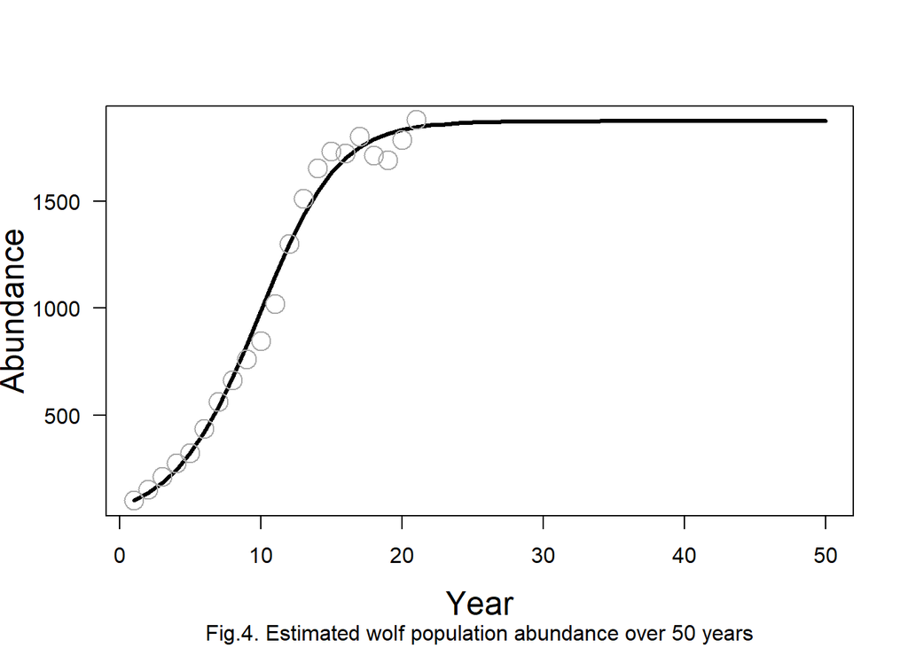

```r
plot( x        = 1 : n_year,
      y        = N_t,
      xlab     = "Year",
      ylab     = "Abundance",
      sub      = "Fig.4. Estimated wolf population abundance over 50 years",
      cex.lab  = 1.5,
      cex      = 2,
      xaxt     = "n",
      type     = "l",
      lwd      = 3,
      las      = 2
)
axis(1)

points( x   = 1 : length(wolf_data$N),
        y   = wolf_data$N,
        pch = 21,
        cex = 2,
        col = "darkgray"
)
```

## Surprising dynamics from this deterministic equation with no variation

Environmental stochasticity could cause K to vary over time. Another mechanism that can cause a population to fluctuate around K has nothing to do with stochasticity. Even deterministically-growing populations can overshoot K when there is a lag in the effect of the proximity of N to K on r. The magnitude of r and the time lag involved can both influence these dynamics.

**Practice:**

1. With different values of $\rho_0$ (between about 1 and 3) in the discrete logistic growth equation estimate abundance to achieve examples of:
1. damped oscillations
2. two-point stable limit cycles
3. four-point stable limit cycles
4. and chaos
2. create a line graph that represents each, with the value of $\rho_0$ that you used labeled on each plot.

Environmental stochasticity is very common in nature – environmental conditions can change over time leading to changes in resources and thus the carrying capacity. Chaos is hard to prove in nature, but it’s likely very rare because it requires that a population have a very high intrinsic growth rate and have discrete population growth (pulsed births/deaths). It is also unlikely that populations that experience this type of growth would persist very long, because the wide fluctuations in abundance lead to a greater chance of extinction.

3. Which of these sources of “noise” around K— stochastic K or damped oscillations/stable limit cycles/chaos— do you think is more common in real wildlife populations? Why?

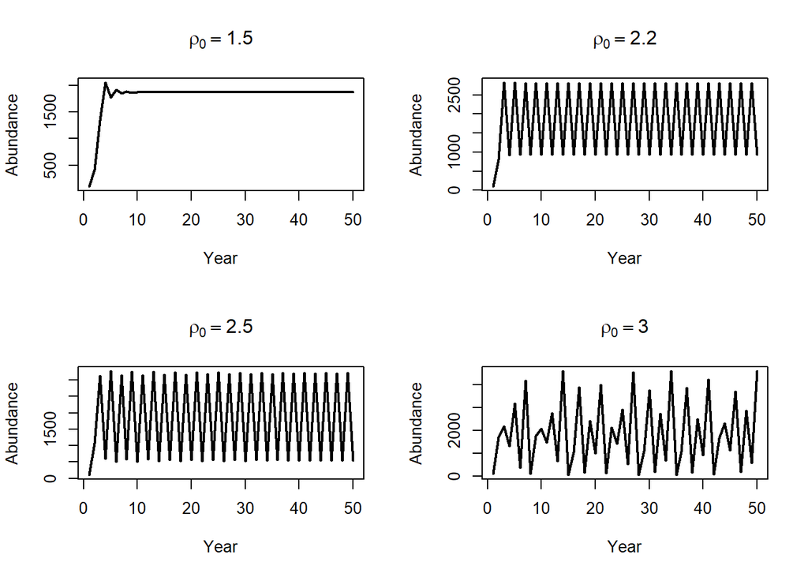

```r
rho_0 <- c(1.5, 2.2, 2.5, 3)
n_year <- 50
N <- rep(NA, n_year)
N[1] <- 101

par(mfrow = c(2, 2))

for (r in 1 : length(rho_0)) {
for (t in 2 : n_year - 1) {
  N[t + 1] <- N[t] * exp(rho_0[r] * (1 - (N[t] / K)))
}

plot(N,
     type = "l",
     lwd  = 2,
     xlab = "Year",
     ylab = "Abundance",
     main = bquote(rho[0] == .(rho_0[r]))
)

}
```